# Day 5: Introduction to Numpy

Amanda Farah

afarah@uchicago.edu

## Goals for the day:

- Create arrays using numpy
- Create n-dimensional arrays
- Do array-wise operations and math
- Create 2D arrays, use linear algebra
- Load data in numpy
- Learn Boolean indexing
- Use various numpy functions

## Functions Learned:

- Import numpy library: `import numpy as np`
- Create a numpy array: `np.arange(start,stop)`
- For floats: `np.linspace(start,stop,num)`
- Make an array of booleans: `bool_array= []`
- Check the shape of a loaded array: `print(data.shape)`
- Check the size of a loaded array: `print(data.size)`
- Check the dtype of a loaded array: `print(data.dtype)`

We need to import a library called `numpy` (short for Numperical Python). Libraries are a collection of lots and lots of code that other people wrote. You can use other people's code to make things easier for you, so you don't have to write it yourself every time you make a new program. Thanks, library developers!

In general you should use NumPy if you want to do fancy things with numbers, especially if you have matrices or arrays. It is the bread and butter of scientific computing with Python! We can load NumPy using: `import numpy as np` where here we are telling python that we will use the nickname `np` every time we really mean `numpy` so that we save time typing.

```python
import numpy as np
```

## 1. Numpy Arrays

`numpy` arrays are the central data structure of the `numpy` library. An array is a grid of values that all have the same type. It can have any number of dimensions and any shape.

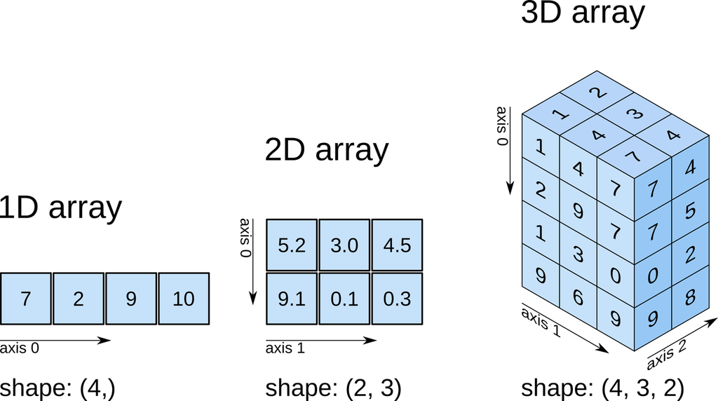

## 1.1 Initialize a 1D array of numbers placed in ascending order.

```python
# np.arange(stop) or np.arange(start,stop) or np.arange(start,stop,step)
# np.arange() is the numpy array version of python's built-in function range()
# it starts at zero and outputs integers by default
print(np.arange(5))
#you can change the default behavior by putting in additional arguments
print(np.arange(3,10,dtype=float))
```

```
[0 1 2 3 4]
[3. 4. 5. 6. 7. 8. 9.]
```

```python
# np.linspace(start,stop,num)
print(np.linspace(0,9) )
```

```
[0.         0.18367347 0.36734694 0.55102041 0.73469388 0.91836735
 1.10204082 1.28571429 1.46938776 1.65306122 1.83673469 2.02040816
 2.20408163 2.3877551  2.57142857 2.75510204 2.93877551 3.12244898
 3.30612245 3.48979592 3.67346939 3.85714286 4.04081633 4.2244898
 4.40816327 4.59183673 4.7755102  4.95918367 5.14285714 5.32653061
 5.51020408 5.69387755 5.87755102 6.06122449 6.24489796 6.42857143
 6.6122449  6.79591837 6.97959184 7.16326531 7.34693878 7.53061224
 7.71428571 7.89795918 8.08163265 8.26530612 8.44897959 8.63265306
 8.81632653 9.        ]
```

```python
#default number of entries is 50, so if you want a different length, must explicitly specify
print(np.linspace(0,9,num=20))
```

```
[0.         0.47368421 0.94736842 1.42105263 1.89473684 2.36842105
 2.84210526 3.31578947 3.78947368 4.26315789 4.73684211 5.21052632
 5.68421053 6.15789474 6.63157895 7.10526316 7.57894737 8.05263158
 8.52631579 9.        ]
```

```python
#Use dtype to change the output format, default is float
print(np.linspace(0,9,num=10,dtype=int))
```

```
[0 1 2 3 4 5 6 7 8 9]
```

## 1.1.1 Check-in [1]: What is the difference between `linspace()` and `arange()`?

What are the differences in default behavior? Under what conditions do they make the same output? When might one be more useful than the other?

Answer these questions briefly in the Slack.

```python
#play around here to answer the above questions
```

### Answer

```python
#range always puts out integers (although they can still have dtype float and act like floats)
#linspace can output numbers with decimals
#you can make linspace act like range if you do this:
print(np.arange(5))
print(np.linspace(0,4,num=5,dtype=int))
```

```
[0 1 2 3 4]
[0 1 2 3 4]
```

```python
def func_to_plot(x):
    return x**2 + 5
```

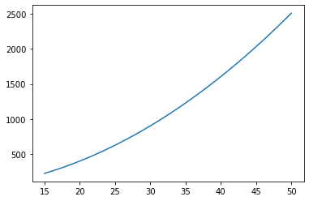

```python
import matplotlib.pyplot as plt

x = np.linspace(15,50)
y = func_to_plot(x)
plt.plot(x,y)
plt.show()
```

## 1.2 Initialize a 1D array from a list of your choosing

Arrays can be initialized from lists, like the ones you made on Day 2.

```python
#make a list here named l
l =  [10,13.4,25.777] #fill me in so you don't get an error!
print(l)
```

```
[10, 13.4, 25.777]
```

```python
arr_from_list = np.array(l)
arr_from_list
```

```
array([10.   , 13.4  , 25.777])
```

## 1.3 Make a 1D numpy array full of zeros/ones.

`np.zeros(10)` `np.ones(10)`

```python
#Make a 1D numpy array full of zeros with 10 elements
a = np.zeros(10,dtype=int)
a
```

```
array([0, 0, 0, 0, 0, 0, 0, 0, 0, 0])
```

## 1.3.1 Check-in [2]:

Make a 1D numpy array full of ones with 13 elements

```python
#now you try: Make a 1D numpy array full of ones with 13 elements
```

### Answer

```python
a = np.ones(13)
a
```

```
array([1., 1., 1., 1., 1., 1., 1., 1., 1., 1., 1., 1., 1.])
```

## 1.4 Make a N-dimensional ndarray full of zeros/ones .

`a = np.zeros((3,3))`

```python
#make an N-dimensional ndarray full of zeros:
#here I will make a 3x5 array:
a = np.zeros((3,5))
a #has 3 rows and 5 columns
```

```
array([[0., 0., 0., 0., 0.],
       [0., 0., 0., 0., 0.],
       [0., 0., 0., 0., 0.]])
```

```python
#check its size and shape!
print(a.size) #should be 3*5
print(a.shape)
```

```
15
(3, 5)
```

## 1.4.1 Check-in [3]:

make a 10x6 2d array full of ones and check its size and shape

```python
#now you try: make an 10X6 ndarray full of ones and check its size and shape
```

### Answer

```python
a = np.ones((10,6))
print(a.shape)
print(a.size)
```

```
(10, 6)
60
```

## 1.5 Initialize an array with random numbers drawn from a distribution of your choosing

numpy has great random number capabilities that are really easy to use. Look up `np.random.uniform(), numpy.random.randint(), numpy.random.seed()` for a few good examples. Here, I'll use the standard Gaussian distribution $\mathcal{N}(0,1)$

```python
# Initializing a random matrix with specified dimensions
# np.random.randn(): Return a sample (or samples) from the “standard normal” distribution.
a = np.random.randn(5,2)
#this should return a 5x2 array full of random samples from N(0,1)
a
```

```
array([[ 1.07477666, -2.5118637 ],
       [-0.37275407,  0.19008447],
       [-0.5941813 ,  0.04880786],
       [ 0.4393388 , -0.93783413],
       [-0.39662578,  1.17075649]])
```

## 1.6 Figure out the datatype of the elements in an array

```python
#lets make a 3x7 ndarray full of 1s
a = np.ones((3,7))
#what datatype did numpy assign to this array?
print(a.dtype)
```

```
float64
```

it assigned it as a float64! This is the default behavior of numpy arrays, but if I want it to be something else I can specify

```python
a = np.ones((3,7),dtype=int)
print(a.dtype)
a = str(a)
a #note that this whole array is a single string now, different rows are separated by "newline"s, indicated by \n
```

```
int64
```

```
'[[1 1 1 1 1 1 1]\n [1 1 1 1 1 1 1]\n [1 1 1 1 1 1 1]]'
```

```python
#if you initialize an array from a list, it will take whatever dtype your list had
arr_from_list.dtype
```

```
dtype('float64')
```

## 2. Reading in Data

```python
loaddir = '../data/' #Make sure the paths end in '/'
savedir = '../output/'
```

The expression `numpy.loadtxt(...)` is a [function call](https://swcarpentry.github.io/python-novice-inflammation/reference.html#function-call) that asks Python to run the function `loadtxt()` that belongs to the numpy library.

`numpy.loadtxt` has two parameters: the name of the file we want to read, and the delimiter that separates values on a line. These both need to be strings, so we put them in quotes.

```python
np.loadtxt(loaddir+'star_formation_rate_MD.csv', delimiter=',')
```

```
array([[ 1.018, -1.958],
       [ 1.055, -1.825],
       [ 1.026, -1.72 ],
       [ 1.124, -1.751],
       [ 1.151, -1.634],
       [ 1.262, -1.692],
       [ 1.308, -1.554],
       [ 1.292, -1.507],
       [ 1.377, -1.416],
       [ 1.485, -1.437],
       [ 1.533, -1.315],
       [ 1.56 , -1.215],
       [ 1.693, -1.241],
       [ 1.693, -1.198],
       [ 1.699, -1.135],
       [ 1.877, -1.108],
       [ 2.008, -1.229],
       [ 1.899, -0.933],
       [ 2.14 , -1.022],
       [ 2.174, -0.954],
       [ 2.098, -0.938],
       [ 2.106, -0.801],
       [ 2.131, -0.837],
       [ 2.449, -0.948],
       [ 2.589, -0.931],
       [ 2.459, -0.826],
       [ 2.77 , -0.741],
       [ 2.837, -0.857],
       [ 3.071, -0.793],
       [ 3.121, -0.735],
       [ 3.299, -0.74 ],
       [ 3.234, -0.851],
       [ 3.247, -0.893],
       [ 3.761, -0.866],
       [ 4.024, -0.966],
       [ 4.008, -1.029],
       [ 4.624, -1.345],
       [ 4.831, -1.271],
       [ 5.006, -1.678],
       [ 6.01 , -1.396],
       [ 6.879, -1.634],
       [ 8.   , -1.781],
       [ 8.032, -1.992],
       [ 8.941, -2.065],
       [ 9.012, -2.187],
       [ 2.518, -0.889]])
```

Cool! Now lets save all that data as a variable

```python
data = np.loadtxt(loaddir+'star_formation_rate_MD.csv', delimiter=',')
```

`data` is now a numpy array that we can work with in the same way that we worked with the ones we created from scratch!